# Lesson 3 — Exploratory Data Analysis

Clinical Data Analysis in R (Phase I) — Pre-course

Neudata

## What this lesson is for

Before testing anything, we **describe** and **look at** the data. You will compute descriptive statistics, build a publication-style summary table, and make the four plots you will use most often: a histogram, a boxplot, a bar plot and a scatterplot — and, just as importantly, **interpret** each one.

```r
library(tidyverse)
library(gtsummary)

clinical_data <- read_csv("../Data/clinical_data_clean.csv")

# A couple of grouped variables for plotting
clinical_data <- clinical_data %>%
  mutate(
    bmi_group = case_when(
      BMI < 18.5 ~ "Underweight",
      BMI < 25   ~ "Normal",
      BMI < 30   ~ "Overweight",
      BMI >= 30  ~ "Obese"
    ),
    bmi_group = factor(bmi_group,
                       levels = c("Underweight", "Normal", "Overweight", "Obese"))
  )
```

## 1. Describing continuous variables

For a continuous variable we usually report the **mean** and **standard deviation** (if roughly symmetric) or the **median** and **IQR** (if skewed).

```r
mean(clinical_data$age)                 # average age
```

```
## [1] 54.23256
```

```r
sd(clinical_data$age)                   # standard deviation
```

```
## [1] 12.48521
```

```r
median(clinical_data$BMI)               # middle value of BMI
```

```
## [1] 26.6
```

```r
IQR(clinical_data$BMI)                  # interquartile range
```

```
## [1] 6.2
```

## 2. Describing categorical variables

For categories we report **counts** and **percentages**.

```r
# Counts
table(clinical_data$smoking)
```

```
##
## Current  Former   Never
##      64     131     235
```

```r
# Proportions (multiply by 100 for percentages)
prop.table(table(clinical_data$smoking)) * 100
```

```
##
##  Current   Former    Never
## 14.88372 30.46512 54.65116
```

```r
# Prevalence of hypertension
mean(clinical_data$hypertension == "Yes") * 100
```

```
## [1] 36.04651
```

## 3. Summaries by group

The clinical question is usually *“does this differ between groups?”* `group_by()` + `summarise()` answers it.

```r
clinical_data %>%
  group_by(sex) %>%
  summarise(
    n        = n(),
    mean_sbp = mean(systolic_bp, na.rm = TRUE),
    mean_bmi = mean(BMI, na.rm = TRUE)
  )
```

```
## # A tibble: 2 × 4
##   sex        n mean_sbp mean_bmi
##   <chr>  <int>    <dbl>    <dbl>
## 1 Female   235     124.     26.6
## 2 Male     195     125.     26.5
```

## 4. A publication-ready “Table 1”

`gtsummary` builds the baseline characteristics table journals expect — in one command.

```r
clinical_data %>%
  select(age, sex, BMI, systolic_bp, diabetes, treatment, hypertension) %>%
  tbl_summary(by = hypertension) %>%
  add_p()                                # adds a p-value column
```

| **Characteristic** | **No** N = 275<sup>1</sup> | **Yes** N = 155<sup>1</sup> | **p-value**<sup>2</sup> |
| --- | --- | --- | --- |
| age | 50 (42, 58) | 62 (54, 69) | <0.001 |
| sex |  |  | 0.5 |
| Female | 154 (56%) | 81 (52%) |  |
| Male | 121 (44%) | 74 (48%) |  |
| BMI | 25.5 (22.8, 28.6) | 28.2 (25.1, 31.1) | <0.001 |
| systolic_bp | 117 (110, 123) | 137 (132, 145) | <0.001 |
| diabetes | 25 (9.1%) | 44 (28%) | <0.001 |
| treatment |  |  | <0.001 |
| Treated | 92 (33%) | 128 (83%) |  |
| Untreated | 183 (67%) | 27 (17%) |  |

<sup>1</sup> Median (Q1, Q3); n (%)  
<sup>2</sup> Wilcoxon rank sum test; Pearson’s Chi-squared test

Read it as: for each characteristic, how the hypertensive and non-hypertensive groups compare.

## 5. Four essential plots

### Histogram — the shape of one continuous variable

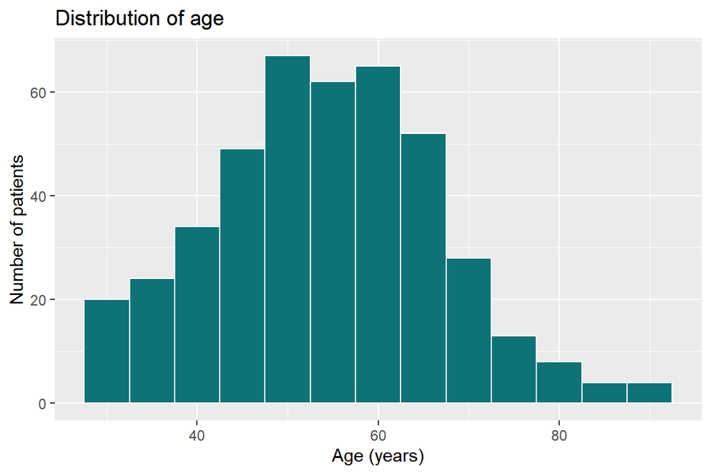

```r
ggplot(clinical_data, aes(x = age)) +
  geom_histogram(binwidth = 5, fill = "#0D7377", colour = "white") +
  labs(title = "Distribution of age", x = "Age (years)", y = "Number of patients")
```

**Interpretation:** age is roughly bell-shaped and centred in the mid-50s — a typical middle-aged clinic population, with no strange spikes.

### Boxplot — a continuous variable across groups

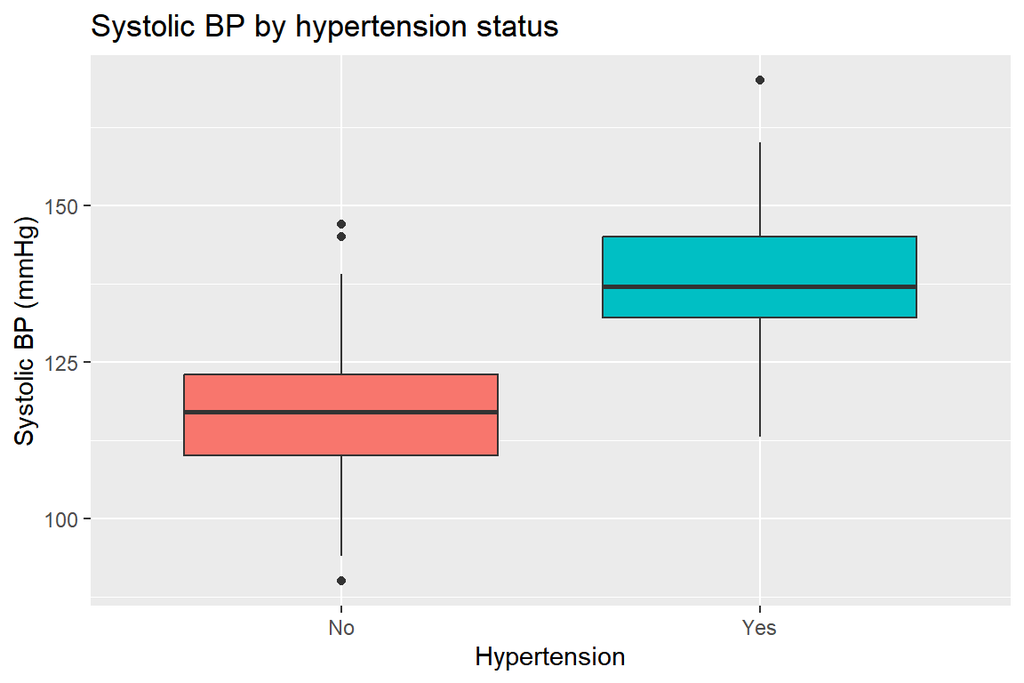

```r
ggplot(clinical_data, aes(x = hypertension, y = systolic_bp, fill = hypertension)) +
  geom_boxplot() +
  labs(title = "Systolic BP by hypertension status",
       x = "Hypertension", y = "Systolic BP (mmHg)") +
  theme(legend.position = "none")
```

**Interpretation:** the box (middle 50% of patients) sits clearly higher for hypertensive patients — as expected. The dots above the whiskers are outliers.

### Bar plot — counts of a category

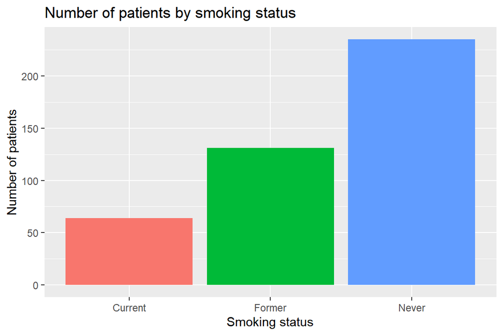

```r
ggplot(clinical_data, aes(x = smoking, fill = smoking)) +
  geom_bar() +
  labs(title = "Number of patients by smoking status",
       x = "Smoking status", y = "Number of patients") +
  theme(legend.position = "none")
```

**Interpretation:** most patients have never smoked, with fewer former and current smokers — useful to know before using smoking as a predictor.

### Scatterplot — two continuous variables together

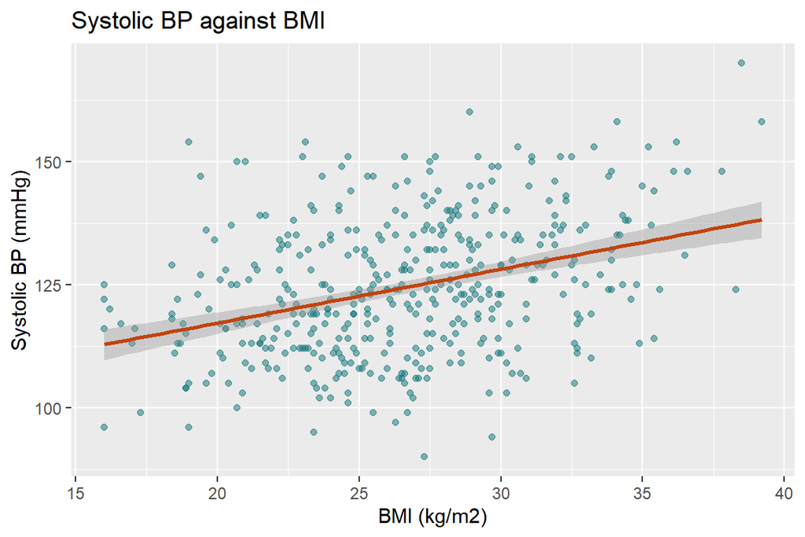

```r
ggplot(clinical_data, aes(x = BMI, y = systolic_bp)) +
  geom_point(alpha = 0.5, colour = "#0D7377") +
  geom_smooth(method = "lm", se = TRUE, colour = "#C1440E") +
  labs(title = "Systolic BP against BMI",
       x = "BMI (kg/m2)", y = "Systolic BP (mmHg)")
```

**Interpretation:** the upward trend line suggests higher BMI is associated with higher systolic blood pressure. A scatterplot is the right first step before a correlation or linear regression.

## Key points to remember

- Continuous data → mean & SD, or median & IQR if skewed.
- Categorical data → counts and percentages (`table()`, `prop.table()`).
- `group_by()` + `summarise()` compares groups.
- `gtsummary::tbl_summary()` builds a Table 1 in one line.
- The four core plots: **histogram** (one variable’s shape), **boxplot** (variable by group), **bar plot** (category counts), **scatterplot** (two continuous variables).
- Always *interpret* a plot in clinical terms — a picture is only useful if you can say what it means.

## Try it yourself

1. Make a histogram of `systolic_bp`. Is it roughly symmetric?
2. Make a boxplot of `BMI` by `sex`. Do men and women differ much?
3. Build a `tbl_summary()` of `age`, `BMI` and `systolic_bp` split `by = sex`.
4. Make a scatterplot of `age` (x) against `systolic_bp` (y) and describe the trend.